Home > Supervised Learning > Bayes and Naive Bayes Classification > Naive Bayes Classification

# 2.2.3.2 Naive Bayes Classification

The problem with Kernel density estimation is that it performs very poorly in high dimensions. While one can calculate 2.2.3.1 Bayes Classification#2.2.12 for $x \in \mathbb{R}^d$ by using a non-negative function $K_\lambda : \mathbb{R}^d \to \mathbb{R}$ with $\int_{\mathbb{R}^d} K_\lambda(x) dy = 1$, an accurate estimation requires an extremely large number of data points, meaning $N$ must be very large. Another problem that we cannot address with the previous methods is the approximation of the conditional probabilities $\mathbb{P}(x|K_x)$ **for mixed variables** $x\in\mathbb{R}^d$, e.g. with qualitative (color) and quantitative (weight) component. An alternative approach that circumvents both difficulties is naive Bayes classification, which operates under the **strong assumption** that the individual features $x_{ij}$ for $j = 1,...,d$ for all data points $x_i$ are independent within a class. In this case, we can use Bayes’ theorem to get:
$$\DeclareMathOperator*{\argmax}{arg\,max}
\mathbb{P}(K_c |x) = \frac{\mathbb{P}(K_c)
\mathbb{P}(x|K_c)}{\sum_{i=1}^C \mathbb{P}(K_i) \mathbb{P}(x|K_i)} =
\frac{\pi_c\prod_{j=1}^d \mathbb{P}(x_j |K_c)}{\sum_{i=1}^C \pi_i
\prod_{j=1}^d \mathbb{P}(x_j|K_i)}$$
remember that $\pi_c$ was considered as the probability $\mathbb{P}(K_c)$ and the estimator was $\hat{\pi}_c := \frac{\#\{i = 1,...,N | y_i = l_c\}}{N}$

or for densities
$$\mathbb{P}(K_c |x)
= \frac{\pi_c\prod_{j=1}^d p(x_j |K_c)}{\sum_{i=1}^C \pi_i
\prod_{j=1}^d p(x_j|K_i)}, \hspace{0.5cm} x \in \mathbb{R}^d$$
Thus, in this case although $x \in \mathbb{R}^d$, we only need to approximate one-dimensional probabilities or densities, namely $\mathbb{P}(x_j |K_c)$ or $p(x_j |K_c)$ for $j = 1,...,d$. This can be achieved using one of the three approaches discussed above. The approximated naive Bayes classifier then becomes
$$x \mapsto
\argmax_{c=1}^C \hspace{0.2cm}\hat{\pi}_c\prod_{j=1}^d \hat{P}(x_j|K_c),
\hspace{0.3cm}\text{ or } \hspace{0.3cm} x \mapsto \argmax_{c=1}^C
\hspace{0.2cm}\hat{\pi}_c\prod_{j=1}^d \hat{p}(x_j|K_c)$$

#### Exercise 2.2.1

Calculate the naive Bayes classifier for the dataset below for x = (195,g, yellow). Use a Gaussian Mixture Model for the weight variable and a discrete model for the color

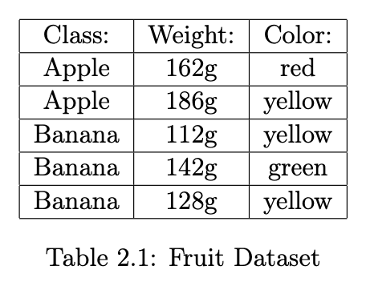

Next chapter: Unsupervised Learning